# hw12

2022-05-28

라이브러리 포함

## 2-A 전처리

데이터 불러오기, 결측치 제거,이상치 제거

```r
air = read.csv("air2.csv")
sum(is.na(air))
```

```
## [1] 0
```

```r
head(air)
```

```
##   측정소명 미세먼지..... 오존.ppm. 일산화탄소농도.ppm. 초미세먼지.....
## 1     중구            29     0.020                 0.4              13
## 2   종로구            28     0.022                 0.4              12
## 3   용산구            34     0.014                 0.4              10
## 4   은평구            26     0.023                 0.5              10
## 5 서대문구            20     0.020                 0.5              10
## 6   마포구            23     0.015                 0.4               9
```

```r
summary(air)
```

```
##    측정소명         미세먼지.....      오존.ppm.       일산화탄소농도.ppm.
##  Length:9100        Min.   :  0.00   Min.   :0.00000   Min.   :0.0000
##  Class :character   1st Qu.: 22.00   1st Qu.:0.01600   1st Qu.:0.3000
##  Mode  :character   Median : 33.00   Median :0.02400   Median :0.4000
##                     Mean   : 35.31   Mean   :0.02542   Mean   :0.4714
##                     3rd Qu.: 46.00   3rd Qu.:0.03300   3rd Qu.:0.6000
##                     Max.   :150.00   Max.   :0.09900   Max.   :1.4000
##  초미세먼지.....
##  Min.   :  0.0
##  1st Qu.: 11.0
##  Median : 18.0
##  Mean   : 20.7
##  3rd Qu.: 27.0
##  Max.   :120.0
```

```r
air <- na.omit(air)
```

이상치 확인

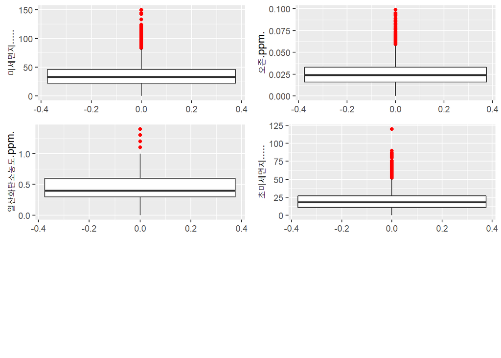

```r
view_plot<-function(data){
    p1<-ggplot(data=data, aes(y=미세먼지.....))+geom_boxplot(outlier.color = 'red')
    p2<-ggplot(data=data, aes(y=오존.ppm.))+geom_boxplot(outlier.color = 'red')

    p3<-ggplot(data=data, aes(y=일산화탄소농도.ppm.))+geom_boxplot(outlier.color = 'red')

    p4<-ggplot(data=data, aes(y=초미세먼지.....))+geom_boxplot(outlier.color = 'red')

    return(grid.arrange(p1,p2,p3,p4,nrow=3))
}
view_plot(air)
```

이상치 제거

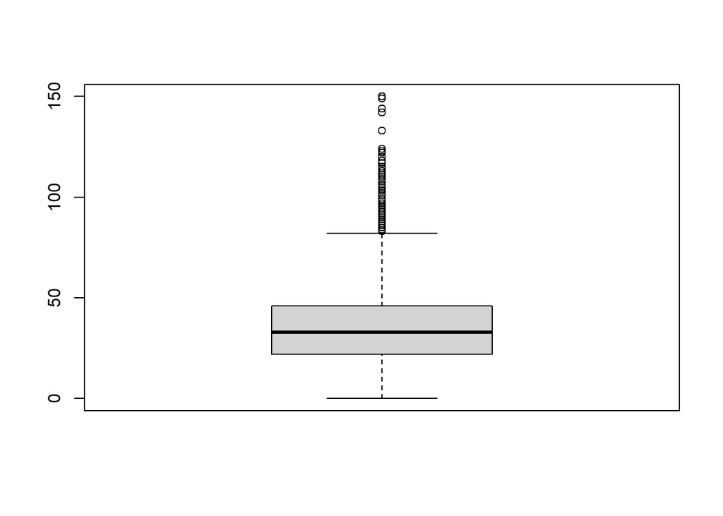

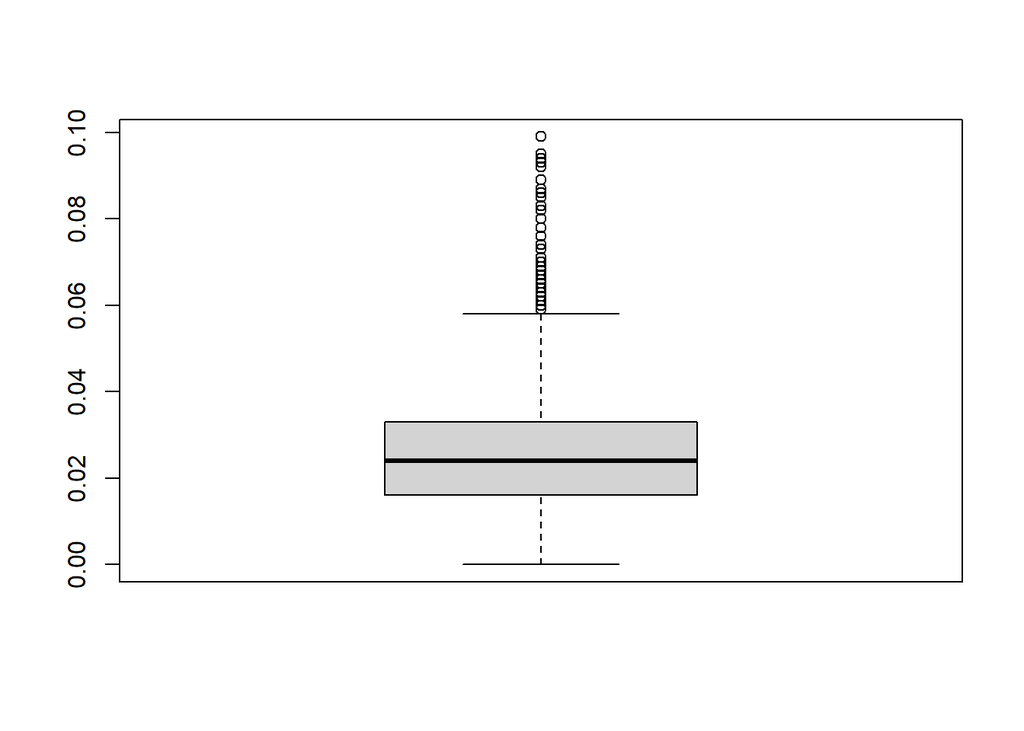

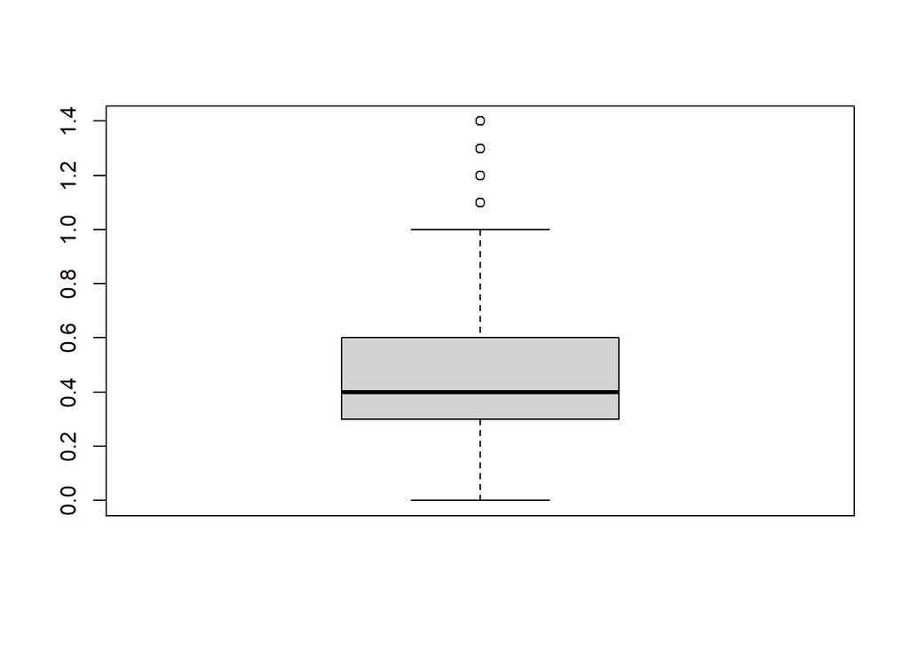

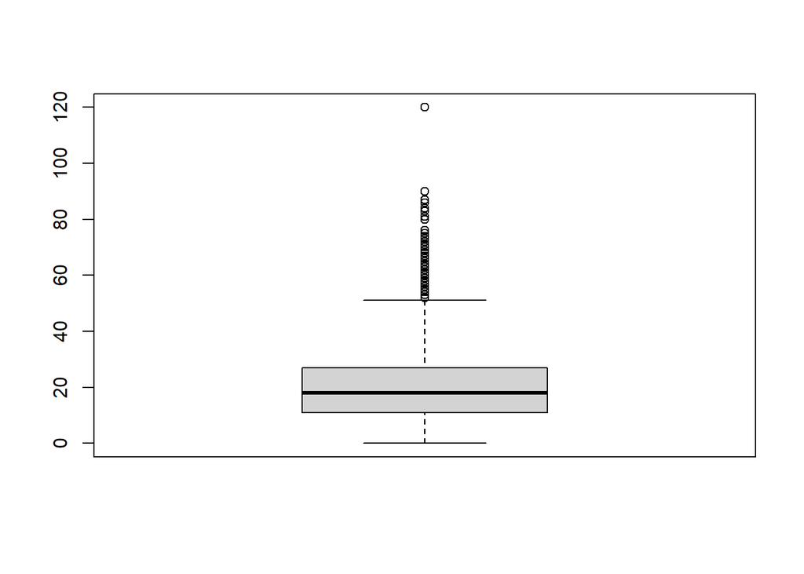

```r
for(i in 2:5){
    air[,i] <- ifelse(air[,i] < boxplot(air[,i])$stats[1] | air[,i] > boxplot(air[,i])$stats[5],NA, air[,i])
}
```

```r
sum(is.na(air))#결측치 개수
```

```
## [1] 518
```

```r
air<-na.omit(air)#결측치포함하는 행 제거
sum(is.na(air))#제거후 결측치 개수 = 0
```

```
## [1] 0
```

데이터 분리  
측정치 데이터 : x  
측정소명 : y

9100개의 데이터를 전부 hclust에 넣었을때 오랜시간 기다려도 결과가 도출이 안되어 데이터를 축소하기로 결정

```r
# hc <- hclust(dist(x, method = "euclidean", diag = TRUE),
#              method = "centroid")
```

2020년 11월에서 12월사이의 결과만으로 축소  
x3: 11월에서 12월 사이의 각 구별 측정치  
y3: 11월에서 12월 측정한 측정 구역역

```r
x3 <-x[1:1526,]
head(x3)
```

```
##   미세먼지..... 오존.ppm. 일산화탄소농도.ppm. 초미세먼지.....
## 1            29     0.020                 0.4              13
## 2            28     0.022                 0.4              12
## 3            34     0.014                 0.4              10
## 4            26     0.023                 0.5              10
## 5            20     0.020                 0.5              10
## 6            23     0.015                 0.4               9
```

```r
y3 <-y[1:1526]
head(y3)
```

```
## [1] "중구"     "종로구"   "용산구"   "은평구"   "서대문구" "마포구"
```

## 3 k-means 군집화 적용

변동성을 없애기 위해 데이터를 스케일링

euclidean을 기준으로 한 거리와 scale

```r
air_dist<- dist(x3, method = "euclidean")# euclidean기준으로 distance 구하기
air_scaled <- scale(x3, center = FALSE, apply(x3, MARGIN = 2, FUN = max)) # x3에 있는 데이터를 최댓값이 1이 되도록 스케일링(변동성이 클수록 결과에 큰 영향을 미치기에 표준화 작업을 거치는것!)
head(air_scaled)
```

```
##   미세먼지..... 오존.ppm. 일산화탄소농도.ppm. 초미세먼지.....
## 1     0.3536585 0.5128205                 0.4       0.2549020
## 2     0.3414634 0.5641026                 0.4       0.2352941
## 3     0.4146341 0.3589744                 0.4       0.1960784
## 4     0.3170732 0.5897436                 0.5       0.1960784
## 5     0.2439024 0.5128205                 0.5       0.1960784
## 6     0.2804878 0.3846154                 0.4       0.1764706
```

```r
air_scaled_dist <- dist(air_scaled, method = "euclidean")
head(air_scaled_dist)# scale 된 데이터를 euclidean기준으로 distance 구하기
```

```
## [1] 0.05624089 0.17563277 0.14393004 0.15970789 0.16715858 0.21521650
```

## 3-A 최적의 K군집

nbclust와 wssplot을 이용하여 몇개의 군집을 만들었을때 가장 효율적인지 알아본다

### 3-A-I

wssplot에서도 2 지점이서 큰 변동이 있는것으로 보임!

```r
nc <- NbClust(x3, min.nc=2, max.nc=15, method="kmeans")#kmeans # nbclust를 사용하여 군집 별 criteria 수치를 알아봄
```

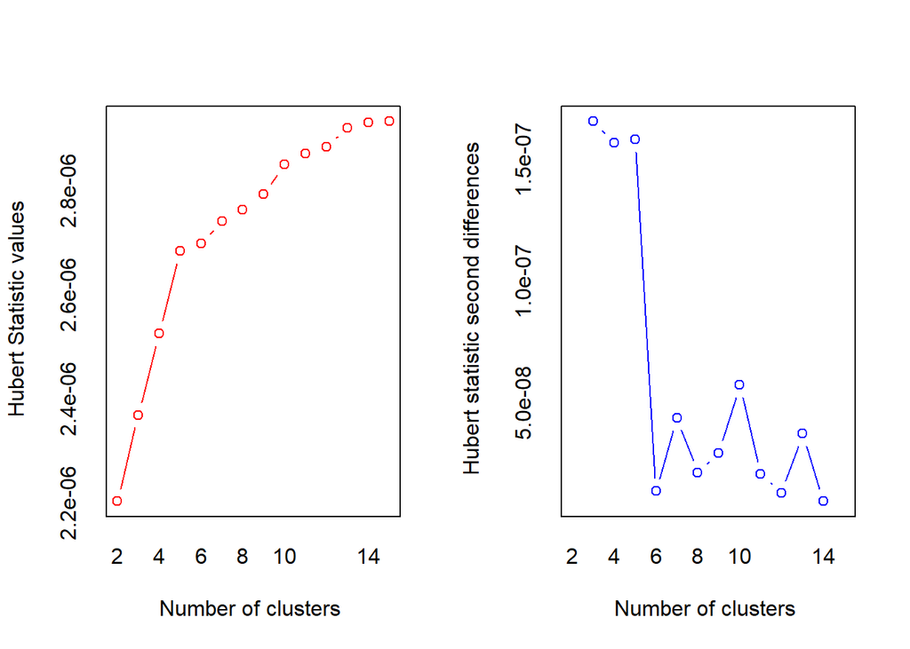

```
## *** : The Hubert index is a graphical method of determining the number of clusters.
##                 In the plot of Hubert index, we seek a significant knee that corresponds to a
##                 significant increase of the value of the measure i.e the significant peak in Hubert
##                 index second differences plot.
##
```

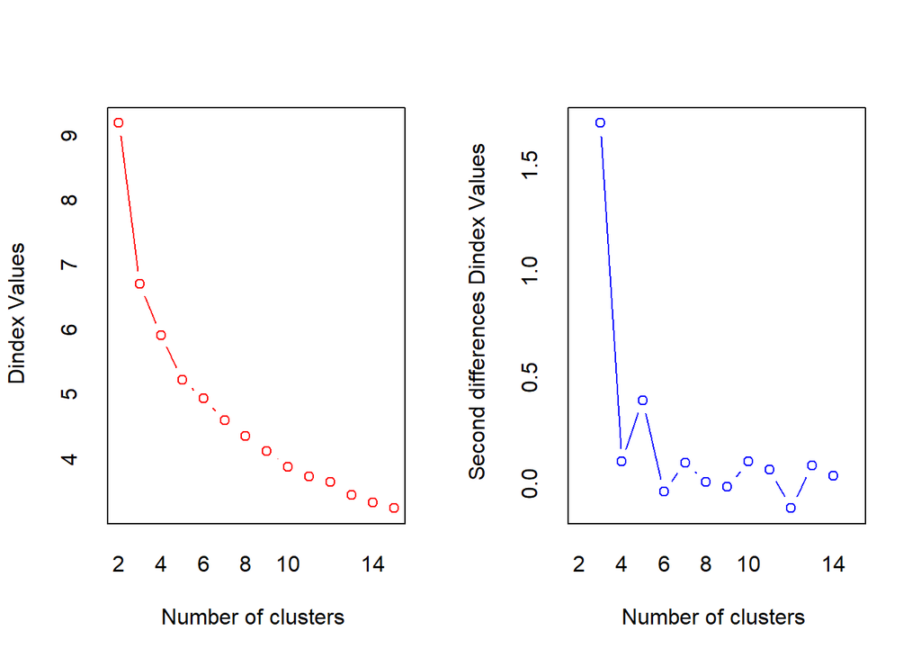

```
## *** : The D index is a graphical method of determining the number of clusters.
##                 In the plot of D index, we seek a significant knee (the significant peak in Dindex
##                 second differences plot) that corresponds to a significant increase of the value of
##                 the measure.
##
## * Among all indices:
## * 7 proposed 2 as the best number of clusters
## * 9 proposed 3 as the best number of clusters
## * 1 proposed 4 as the best number of clusters
## * 5 proposed 13 as the best number of clusters
## * 1 proposed 14 as the best number of clusters
## * 1 proposed 15 as the best number of clusters
##
##                    ***** Conclusion *****
##
## * According to the majority rule, the best number of clusters is  3
##
##
```

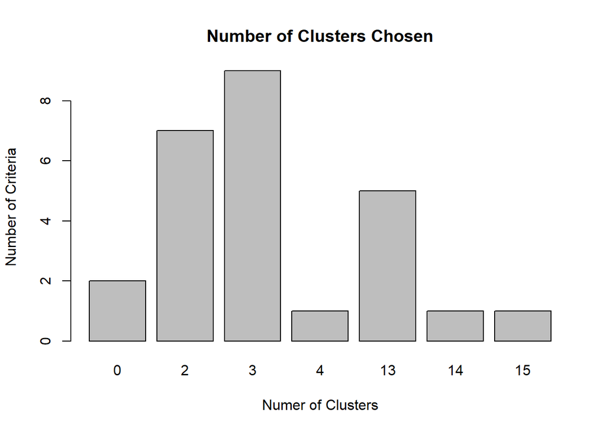

```r
par(mfrow=c(1,1))
barplot(table(nc$Best.n[1,]), # 군집이 3인경우 criteria가 최대!
        xlab="Numer of Clusters", ylab="Number of Criteria",
        main="Number of Clusters Chosen")
```

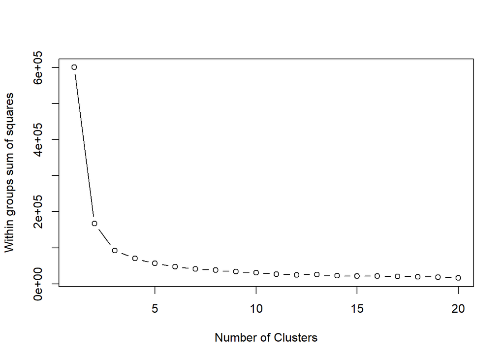

```r
wssplot <- function(data, nc=20, seed=1234){
  wss <- (nrow(data)-1)*sum(apply(data,2,var)) # K = 1, Total SS
  for (i in 2:nc){
    set.seed(seed)
    wss[i] <- sum(kmeans(data, centers=i)$withinss)}
  plot(1:nc, wss, type="b", xlab="Number of Clusters",
       ylab="Within groups sum of squares")
}

wssplot(x3)
```

2개의 군집으로 만든 plot과 table

```r
air.kmeans <- kmeans(x3, centers = 2, nstart = 25)
head(air.kmeans)
```

```
## $cluster
##    1    2    3    4    5    6    7    8    9   10   11   12   13   14   15   16
##    1    1    1    1    1    1    1    1    1    1    1    1    1    1    1    1
##   17   18   19   20   21   22   23   24   25   26   27   28   29   30   31   32
##    1    1    1    1    1    1    1    1    1    1    1    1    1    1    1    1
##   33   34   35   36   37   38   39   40   41   42   43   44   45   46   47   48
##    1    1    1    1    1    1    1    1    1    1    1    1    1    1    1    1
##   49   50   51   52   53   54   55   56   57   58   59   60   61   62   63   64
##    1    1    2    2    2    2    2    2    2    2    2    2    2    2    2    2
##   65   68   69   70   72   74   75   76   77   78   79   80   81   82   83   84
##    2    2    2    2    2    2    2    2    2    2    2    2    2    2    2    2
##   85   86   87   88   89   90   91   92   93   94   95   96   97   98   99  101
##    2    2    2    2    2    2    2    2    2    2    2    2    2    2    2    2
##  102  103  104  105  106  107  108  109  110  111  112  113  114  115  116  117
##    2    2    2    2    2    2    2    2    2    2    2    2    2    2    2    2
```

[output cut: 195 more lines]

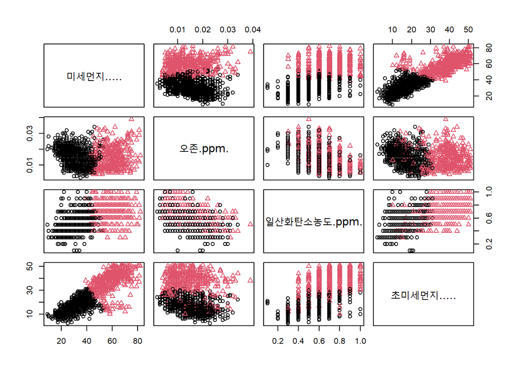

```r
plot(x3, pch = air.kmeans$cluster, col = air.kmeans$cluster)
```

```r
table(air.kmeans$cluster,y3)
```

```
##    y3
##     강남구 강동구 강북구 강서구 관악구 광진구 구로구 금천구 노원구 도봉구
##   1     44     36     40     41     45     43     41     42     42     43
##   2     18     21     23     19     18     20     18     18     20     20
##    y3
##     동대문구 동작구 마포구 서대문구 서초구 성동구 성북구 송파구 양천구 영등포구
##   1       44     42     46       44     40     45     40     44     38       45
##   2       19     21     16       14     16     19     16     19     19       15
##    y3
##     용산구 은평구 종로구 중구 중랑구
##   1     42     44     41   35     43
##   2     22     18     21   25     21
```

## 3-A-II

euclidean을 기준으로한 dendrogram

```r
hc <- hclust(dist(x3, method = "euclidean", diag = TRUE),
             method = "centroid")

hc
```

```
##
## Call:
## hclust(d = dist(x3, method = "euclidean", diag = TRUE), method = "centroid")
##
## Cluster method   : centroid
## Distance         : euclidean
## Number of objects: 1526
```

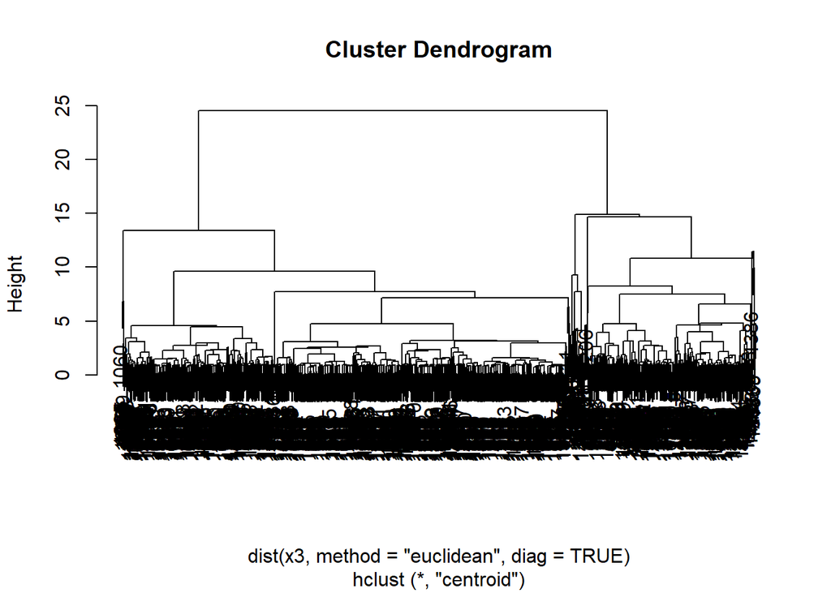

```r
plot(hc)
```

```r
clus<-cutree(hc, k = 2)
table(clus)
```

```
## clus
##    1    2
## 1079  447
```

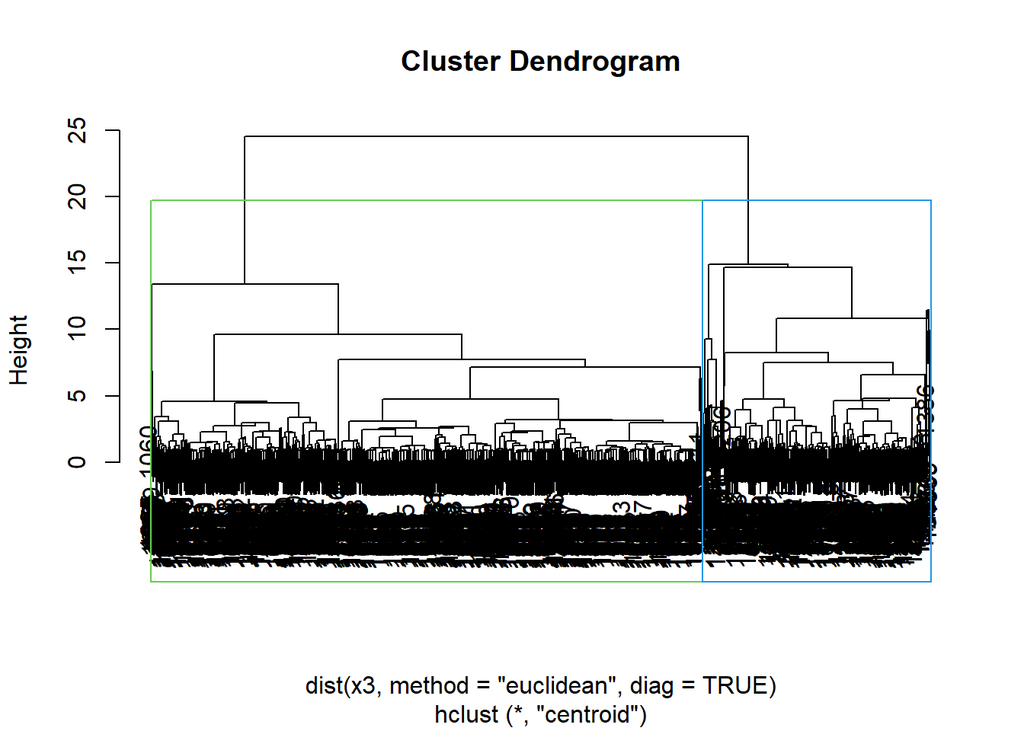

```r
plot.new() # or frame()

plot(hc)
#군집간 네모박스
rect.hclust(hc, k = 2, border = 3:5)

abline(h = 36, col="red")
```

## 3-B-III 거리 척도에 대한 척도 선택

유클리드거리와 맨하튼 거리 비교

withinss 는 응집도를 의미하며 수치가 작을수록 잘 응집됨을 의미한다  
유클리드거리와 맨하튼 거리를 비교하였을때 유클리드 거리가 더 작음으로 유클리드 거리의 성능이 더 좋다고 할 수 있다

=>거리 척도 유클리드 선택

```r
euclidean_kmeans <- Kmeans(x3, centers = 2, nstart = 25,method = "euclidean")

manhattan_kmeans <- Kmeans(x3, centers = 2, nstart = 25,method = "manhattan")


euclidean_kmeans$withinss
```

```
## [1] 219.9357 319.6173
```

```r
manhattan_kmeans$withinss
```

```
## [1] 624.0049 455.6180
```

## 3-B-i-1,2

오존과 일산화탄소는 제외하고 11~12월의 미세먼지 대기 상태를 분석하기로 결정  
눈으로 보았을때 군집화가 잘되어 보이는 초미세먼지와 미세먼지를 선택

```r
head(x3)
```

```
##   미세먼지..... 오존.ppm. 일산화탄소농도.ppm. 초미세먼지.....
## 1            29     0.020                 0.4              13
## 2            28     0.022                 0.4              12
## 3            34     0.014                 0.4              10
## 4            26     0.023                 0.5              10
## 5            20     0.020                 0.5              10
## 6            23     0.015                 0.4               9
```

```r
x0<-x3[,-c(2,3)]
head(x0)
```

```
##   미세먼지..... 초미세먼지.....
## 1            29              13
## 2            28              12
## 3            34              10
## 4            26              10
## 5            20              10
## 6            23               9
```

```r
y0<-y3
```

euclidean을 활용한 변수들간의 거리와 scale  
이번에는 scale된 군집을 살펴볼 예정

```r
air_dist<- dist(x0, method = "euclidean")
air_scaled <- scale(x0, center = FALSE, apply(x0, MARGIN = 2, FUN = max))
head(air_scaled)
```

```
##   미세먼지..... 초미세먼지.....
## 1     0.3536585       0.2549020
## 2     0.3414634       0.2352941
## 3     0.4146341       0.1960784
## 4     0.3170732       0.1960784
## 5     0.2439024       0.1960784
## 6     0.2804878       0.1764706
```

```r
air_scaled_dist <- dist(air_scaled, method = "euclidean")
head(air_scaled_dist)
```

```
## [1] 0.02309088 0.08472445 0.06927263 0.12452553 0.10726340 0.06405070
```

```r
head(x0)
```

```
##   미세먼지..... 초미세먼지.....
## 1            29              13
## 2            28              12
## 3            34              10
## 4            26              10
## 5            20              10
## 6            23               9
```

```r
nc <- NbClust(air_scaled, min.nc=2, max.nc=15, method="kmeans")#kmeans
```

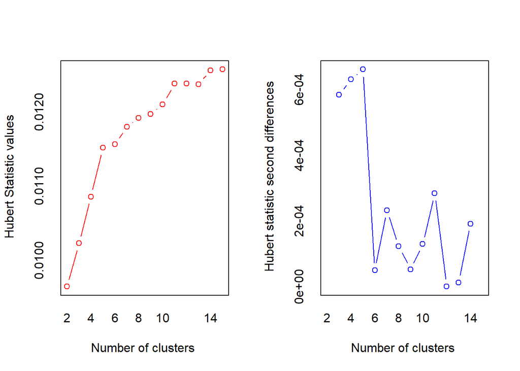

```
## *** : The Hubert index is a graphical method of determining the number of clusters.
##                 In the plot of Hubert index, we seek a significant knee that corresponds to a
##                 significant increase of the value of the measure i.e the significant peak in Hubert
##                 index second differences plot.
##
```

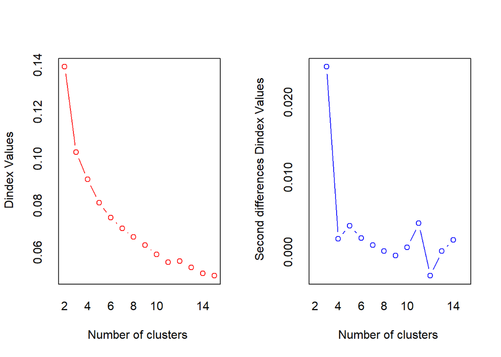

```
## *** : The D index is a graphical method of determining the number of clusters.
##                 In the plot of D index, we seek a significant knee (the significant peak in Dindex
##                 second differences plot) that corresponds to a significant increase of the value of
##                 the measure.
##
## * Among all indices:
## * 8 proposed 2 as the best number of clusters
## * 7 proposed 3 as the best number of clusters
## * 1 proposed 4 as the best number of clusters
## * 1 proposed 6 as the best number of clusters
## * 3 proposed 11 as the best number of clusters
## * 1 proposed 12 as the best number of clusters
## * 3 proposed 15 as the best number of clusters
##
##                    ***** Conclusion *****
##
## * According to the majority rule, the best number of clusters is  2
##
##
```

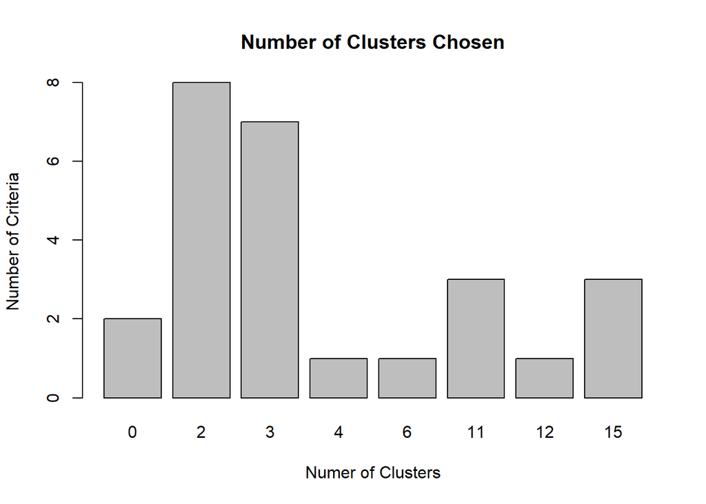

```r
par(mfrow=c(1,1))
barplot(table(nc$Best.n[1,]), # 군집이 2인경우 criteria가 최대!
        xlab="Numer of Clusters", ylab="Number of Criteria",
        main="Number of Clusters Chosen")
```

scale된 미세먼지와 초미세먼지를 바탕으로 kmeans진행

```r
air1.kmeans <- kmeans(air_scaled, centers = 2, nstart = 25)
head(air1.kmeans)
```

```
## $cluster
##    1    2    3    4    5    6    7    8    9   10   11   12   13   14   15   16
##    2    2    2    2    2    2    2    2    2    2    2    2    2    2    2    2
##   17   18   19   20   21   22   23   24   25   26   27   28   29   30   31   32
##    2    2    2    2    2    2    2    2    2    2    2    2    2    2    2    2
##   33   34   35   36   37   38   39   40   41   42   43   44   45   46   47   48
##    2    2    2    2    2    2    2    2    2    2    2    2    2    2    2    2
##   49   50   51   52   53   54   55   56   57   58   59   60   61   62   63   64
##    2    2    1    1    1    1    1    1    1    1    1    1    1    1    1    1
##   65   68   69   70   72   74   75   76   77   78   79   80   81   82   83   84
##    1    1    1    1    1    1    1    1    1    1    1    1    1    1    1    1
##   85   86   87   88   89   90   91   92   93   94   95   96   97   98   99  101
##    1    1    1    1    1    1    1    1    1    1    1    1    1    1    1    1
##  102  103  104  105  106  107  108  109  110  111  112  113  114  115  116  117
##    1    1    1    1    1    1    1    1    1    1    1    1    1    1    1    1
```

[output cut: 195 more lines]

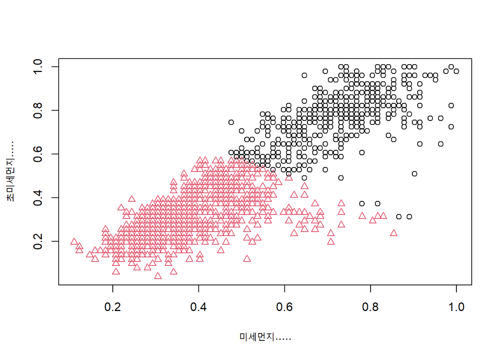

```r
plot(air_scaled, pch = air1.kmeans$cluster, col = air1.kmeans$cluster)
```

```r
table(air1.kmeans$cluster,y0)
```

```
##    y0
##     강남구 강동구 강북구 강서구 관악구 광진구 구로구 금천구 노원구 도봉구
##   1     18     20     21     17     18     20     15     17     21     19
##   2     44     37     42     43     45     43     44     43     41     44
##    y0
##     동대문구 동작구 마포구 서대문구 서초구 성동구 성북구 송파구 양천구 영등포구
##   1       19     19     16       13     15     19     15     19     17       16
##   2       44     44     46       45     41     45     41     44     40       44
##    y0
##     용산구 은평구 종로구 중구 중랑구
##   1     20     16     20   20     20
##   2     44     46     42   40     44
```

```r
aa<-air1.kmeans$centers
head(air1.kmeans$cluster)
```

```
## 1 2 3 4 5 6
## 2 2 2 2 2 2
```

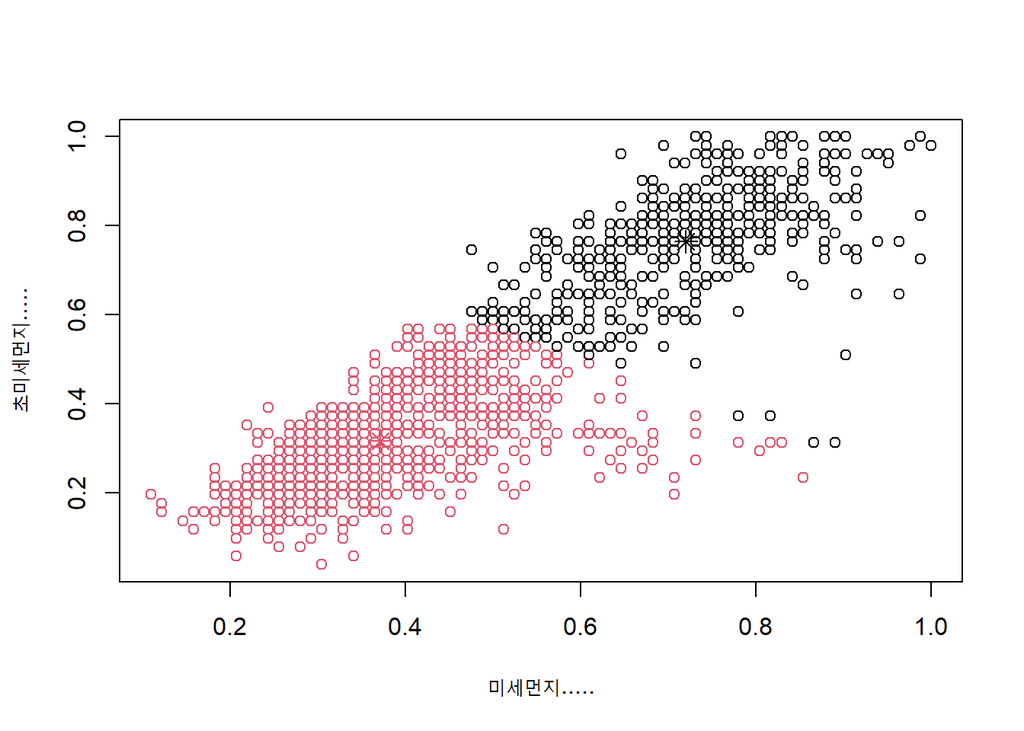

```r
plot(air_scaled, col=air1.kmeans$cluster)
points(air1.kmeans$centers,col=1:3, pch=8,cex=1.5)
```

##3-B-II 초기중심 변경을 위해 2번의 kmeans 군집화!

```r
air11.kmeans <- kmeans(air_scaled, centers = 2, nstart = 25)
head(air11.kmeans)
```

```
## $cluster
##    1    2    3    4    5    6    7    8    9   10   11   12   13   14   15   16
##    1    1    1    1    1    1    1    1    1    1    1    1    1    1    1    1
##   17   18   19   20   21   22   23   24   25   26   27   28   29   30   31   32
##    1    1    1    1    1    1    1    1    1    1    1    1    1    1    1    1
##   33   34   35   36   37   38   39   40   41   42   43   44   45   46   47   48
##    1    1    1    1    1    1    1    1    1    1    1    1    1    1    1    1
##   49   50   51   52   53   54   55   56   57   58   59   60   61   62   63   64
##    1    1    2    2    2    2    2    2    2    2    2    2    2    2    2    2
##   65   68   69   70   72   74   75   76   77   78   79   80   81   82   83   84
##    2    2    2    2    2    2    2    2    2    2    2    2    2    2    2    2
##   85   86   87   88   89   90   91   92   93   94   95   96   97   98   99  101
##    2    2    2    2    2    2    2    2    2    2    2    2    2    2    2    2
##  102  103  104  105  106  107  108  109  110  111  112  113  114  115  116  117
##    2    2    2    2    2    2    2    2    2    2    2    2    2    2    2    2
```

[output cut: 195 more lines]

```r
#plot(air_scaled, pch = air11.kmeans$cluster, col = air1.kmeans$cluster)
table(air11.kmeans$cluster,y0)
```

```
##    y0
##     강남구 강동구 강북구 강서구 관악구 광진구 구로구 금천구 노원구 도봉구
##   1     44     37     42     43     45     43     44     43     41     44
##   2     18     20     21     17     18     20     15     17     21     19
##    y0
##     동대문구 동작구 마포구 서대문구 서초구 성동구 성북구 송파구 양천구 영등포구
##   1       44     44     46       45     41     45     41     44     40       44
##   2       19     19     16       13     15     19     15     19     17       16
##    y0
##     용산구 은평구 종로구 중구 중랑구
##   1     44     46     42   40     44
##   2     20     16     20   20     20
```

```r
aaa<-air11.kmeans$centers
head(air11.kmeans$cluster)
```

```
## 1 2 3 4 5 6
## 1 1 1 1 1 1
```

```r
air111.kmeans <- kmeans(air_scaled, centers = 2, nstart = 25)
head(air111.kmeans)
```

```
## $cluster
##    1    2    3    4    5    6    7    8    9   10   11   12   13   14   15   16
##    2    2    2    2    2    2    2    2    2    2    2    2    2    2    2    2
##   17   18   19   20   21   22   23   24   25   26   27   28   29   30   31   32
##    2    2    2    2    2    2    2    2    2    2    2    2    2    2    2    2
##   33   34   35   36   37   38   39   40   41   42   43   44   45   46   47   48
##    2    2    2    2    2    2    2    2    2    2    2    2    2    2    2    2
##   49   50   51   52   53   54   55   56   57   58   59   60   61   62   63   64
##    2    2    1    1    1    1    1    1    1    1    1    1    1    1    1    1
##   65   68   69   70   72   74   75   76   77   78   79   80   81   82   83   84
##    1    1    1    1    1    1    1    1    1    1    1    1    1    1    1    1
##   85   86   87   88   89   90   91   92   93   94   95   96   97   98   99  101
##    1    1    1    1    1    1    1    1    1    1    1    1    1    1    1    1
##  102  103  104  105  106  107  108  109  110  111  112  113  114  115  116  117
##    1    1    1    1    1    1    1    1    1    1    1    1    1    1    1    1
```

[output cut: 195 more lines]

```r
#plot(air_scaled, pch = air111.kmeans$cluster, col = air1.kmeans$cluster)
table(air111.kmeans$cluster,y0)
```

```
##    y0
##     강남구 강동구 강북구 강서구 관악구 광진구 구로구 금천구 노원구 도봉구
##   1     18     20     21     17     18     20     15     17     21     19
##   2     44     37     42     43     45     43     44     43     41     44
##    y0
##     동대문구 동작구 마포구 서대문구 서초구 성동구 성북구 송파구 양천구 영등포구
##   1       19     19     16       13     15     19     15     19     17       16
##   2       44     44     46       45     41     45     41     44     40       44
##    y0
##     용산구 은평구 종로구 중구 중랑구
##   1     20     16     20   20     20
##   2     44     46     42   40     44
```

```r
aaaa<-air111.kmeans$centers
head(air111.kmeans$cluster)
```

```
## 1 2 3 4 5 6
## 2 2 2 2 2 2
```

## 3-C

같은 scale된 데이터를 이용하여 3번의 kmeans진행!

3번의 무작위 시작점에도 불구하고 3번 다 같은 결과가 나옴!

=> 군집화가 매우 잘됨

```r
aa
```

```
##   미세먼지..... 초미세먼지.....
## 1     0.7201626       0.7650545
## 2     0.3715545       0.3170238
```

```r
aaa
```

```
##   미세먼지..... 초미세먼지.....
## 1     0.3715545       0.3170238
## 2     0.7201626       0.7650545
```

```r
aaaa
```

```
##   미세먼지..... 초미세먼지.....
## 1     0.7201626       0.7650545
## 2     0.3715545       0.3170238
```

응집도와 분리도를 이용하여 kmeans데이터의 성능을 측정

```r
#응집도: 클러스터 안에 얼마나 데이터가 뭉쳐져 있는가
air1.kmeans$withinss # 작아야 좋음
```

```
## [1] 12.98459 25.39667
```

```r
# 분리도: 다른 클러스터간 얼마나 떨어져 있는가
air1.kmeans$betweenss # 커야 좋음
```

```
## [1] 102.2528
```

```r
aa<-air1.kmeans$centers
```

정확한 수치를 알아보기 위해 2가지 군집의 비율 계산

```r
table(air1.kmeans$cluster,y0)
```

```
##    y0
##     강남구 강동구 강북구 강서구 관악구 광진구 구로구 금천구 노원구 도봉구
##   1     18     20     21     17     18     20     15     17     21     19
##   2     44     37     42     43     45     43     44     43     41     44
##    y0
##     동대문구 동작구 마포구 서대문구 서초구 성동구 성북구 송파구 양천구 영등포구
##   1       19     19     16       13     15     19     15     19     17       16
##   2       44     44     46       45     41     45     41     44     40       44
##    y0
##     용산구 은평구 종로구 중구 중랑구
##   1     20     16     20   20     20
##   2     44     46     42   40     44
```

```r
good<-sum(table(air1.kmeans$cluster,y0)[1,])
bad<-sum(table(air1.kmeans$cluster,y0)[2,])

good/sum(bad,good)
```

```
## [1] 0.2948886
```

```r
bad/sum(bad,good)
```

```
## [1] 0.7051114
```

## 3-D 각 군집에 대한 labelling

미세먼지와 초미세먼지를 바탕으로한 군집인 만큼 비례적인 특성을 가짐

두가지의 군집이 수치가 큰것과 낮은 것 두 부분으로 나눌 수 있음으로  
빨간색은 미세먼지가 좋음 검은색은 나쁨으로 표현 할 수 있음

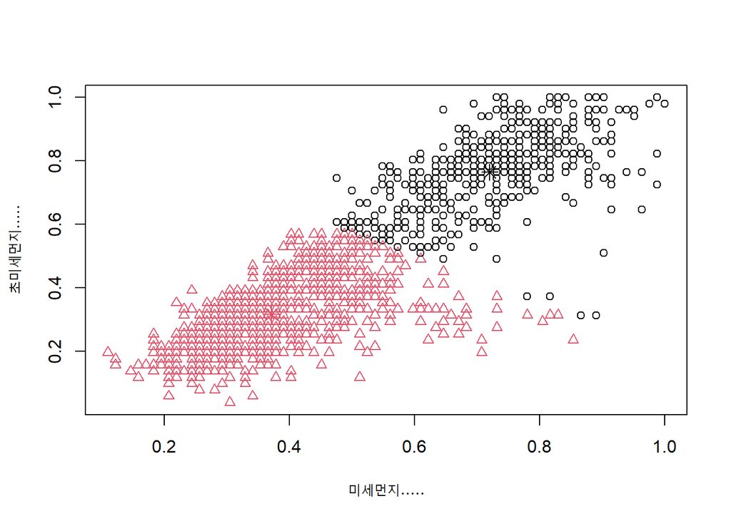

```r
plot(air_scaled, col=air1.kmeans$cluster,, pch = air1.kmeans$cluster)
points(air1.kmeans$centers,col=1:3, pch=8,cex=1.5)
```

```r
table(air1.kmeans$cluster,y0)
```

```
##    y0
##     강남구 강동구 강북구 강서구 관악구 광진구 구로구 금천구 노원구 도봉구
##   1     18     20     21     17     18     20     15     17     21     19
##   2     44     37     42     43     45     43     44     43     41     44
##    y0
##     동대문구 동작구 마포구 서대문구 서초구 성동구 성북구 송파구 양천구 영등포구
##   1       19     19     16       13     15     19     15     19     17       16
##   2       44     44     46       45     41     45     41     44     40       44
##    y0
##     용산구 은평구 종로구 중구 중랑구
##   1     20     16     20   20     20
##   2     44     46     42   40     44
```

kmeans 결과 고찰

군집은 두가지로 나누어지며 초미세먼지와 미세먼지는 비례적인 특징을 가진다  
nbclust의 결과로 보았을때, 2가지 군집으로 나누어졌다.  
비례적인 특성으로 보았을때, 2가지 군집은 각각 대기상태가 좋음/나쁨 으로 구분할수 있다.  
빨간색 날짜의 지역의 경우 대기상태가 좋음을 의미한다  
검은색 날짜의 지역의 경우 대기상태가 나쁨을 의미한다

11~12월은 북서풍이 시작이 되는 시기로 미세먼지로인한 대기 상태가 나빠지기 시작하는 시점이라고 할 수 있다

ㅡㅡㅡㅡㅡㅡㅡㅡㅡㅡㅡㅡㅡㅡㅡㅡㅡㅡㅡㅡㅡㅡㅡㅡㅡㅡㅡㅡㅡㅡㅡㅡㅡㅡㅡㅡㅡㅡㅡㅡㅡㅡㅡㅡㅡㅡㅡㅡㅡㅡ

## 4-A 다른 군집화와 비교

eps : 도달 가능한 거리. 이것은 이웃들의 크기를 정의한다.  
MinPts: 거리내에 있어야만 하는 최소 점들의 개수.

eps의 최적값을 구하기위해 dbscan페키지의 knndistplot을 그려서 elbow포인트를 찾아본다

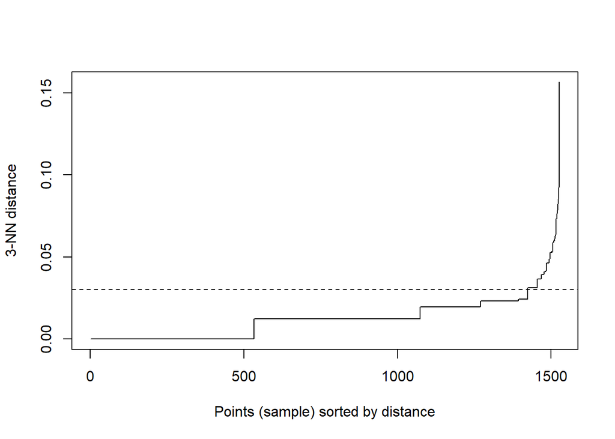

```r
dbscan::kNNdistplot(air_scaled, k=3)
abline(h = 0.03, lty = 2)
```

dbscan 군집화 실행

```r
ds<- dbscan(air_scaled, eps=0.03, MinPts=4)
head(ds)
```

```
## $cluster
##    [1] 1 1 1 1 1 1 1 1 1 1 1 1 1 1 1 1 1 1 1 1 1 1 1 1 1 1 1 0 1 1 1 1 1 1 1 1 1
##   [38] 1 1 1 0 1 1 1 1 1 1 1 1 1 1 1 2 1 0 1 1 1 1 1 1 1 1 1 0 1 1 1 1 1 1 1 1 1
##   [75] 1 1 1 1 1 1 1 1 1 1 1 1 1 1 1 1 1 1 1 1 1 2 1 1 1 1 1 1 1 1 1 1 1 1 1 1 1
##  [112] 1 1 1 1 1 1 1 1 0 1 1 0 1 1 1 1 1 1 1 1 1 1 1 1 1 1 1 1 1 1 1 1 1 1 1 1 1
##  [149] 1 1 1 1 1 1 1 1 1 1 1 1 1 1 1 1 1 1 1 1 1 1 1 1 1 1 1 1 1 1 1 1 1 1 1 1 1
##  [186] 1 1 1 1 1 1 1 1 1 1 1 0 1 1 1 1 1 1 1 1 1 1 1 1 1 1 1 1 1 0 1 1 1 1 1 1 1
##  [223] 1 1 1 1 1 1 1 1 1 1 0 1 1 1 1 1 1 1 1 1 1 1 1 1 1 1 1 1 1 1 1 1 1 1 1 1 1
##  [260] 1 1 1 1 1 1 1 1 1 1 1 1 1 1 1 1 1 1 1 1 1 1 1 1 1 1 1 1 1 1 1 1 1 1 1 1 1
##  [297] 1 1 1 1 1 1 1 1 1 1 1 1 1 1 1 1 1 1 1 1 1 1 1 1 1 1 1 1 1 1 1 1 1 1 1 1 1
##  [334] 1 1 1 1 1 1 1 1 1 1 1 1 1 1 1 1 1 1 1 1 1 1 1 1 1 1 1 1 1 1 1 1 1 1 1 1 1
##  [371] 1 1 1 1 1 1 1 1 1 1 1 1 1 1 1 1 1 1 1 1 1 1 1 1 1 0 1 1 1 1 1 1 1 1 1 1 1
##  [408] 1 1 1 1 1 1 1 1 1 1 1 1 1 1 1 1 1 1 1 1 1 1 1 1 1 1 1 1 1 1 1 1 1 1 1 1 1
##  [445] 1 1 1 1 1 1 1 1 1 1 1 1 1 1 1 1 1 1 1 1 1 1 1 1 1 1 1 1 1 1 1 1 1 1 1 1 1
##  [482] 1 1 1 1 1 1 1 0 1 1 1 1 1 1 1 1 1 1 1 1 1 1 1 1 1 1 1 1 1 1 1 1 1 1 1 1 1
```

[output cut: 34 more lines]

```r
table(ds$cluster, y0)
```

```
##    y0
##     강남구 강동구 강북구 강서구 관악구 광진구 구로구 금천구 노원구 도봉구
##   0      1      2      1      3      2      1      7      1      2      3
##   1     61     55     62     57     61     62     52     59     60     60
##   2      0      0      0      0      0      0      0      0      0      0
##    y0
##     동대문구 동작구 마포구 서대문구 서초구 성동구 성북구 송파구 양천구 영등포구
##   0        2      2      3        5      2      2      6      1      1        2
##   1       61     61     59       53     54     62     50     62     56       58
##   2        0      0      0        0      0      0      0      0      0        0
##    y0
##     용산구 은평구 종로구 중구 중랑구
##   0      9      2      1    5      1
##   1     54     60     60   52     63
##   2      1      0      1    3      0
```

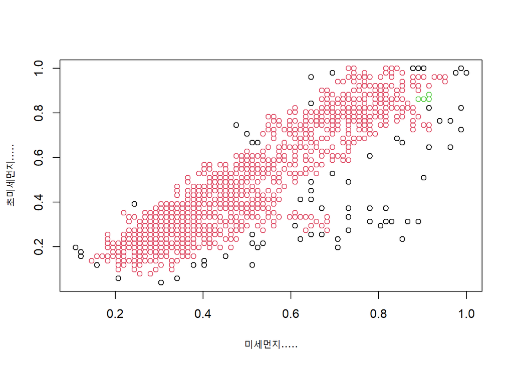

```r
plot(ds, air_scaled)
```

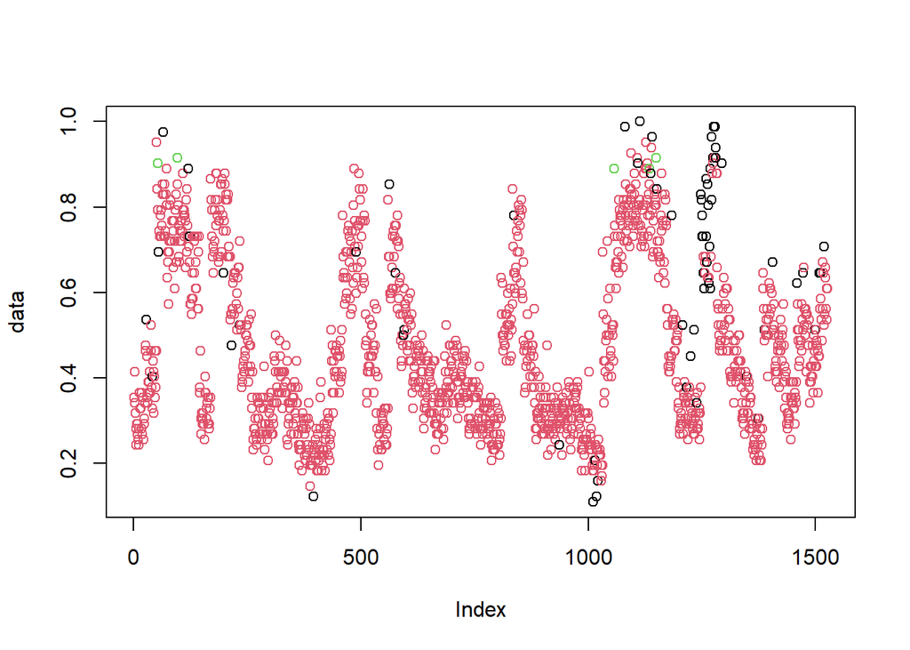

```r
plot(ds, air_scaled[,-c(2,3)])
```

factoextra 라이브러리를 사용하여 labelling 시도

```r
library("factoextra")
```

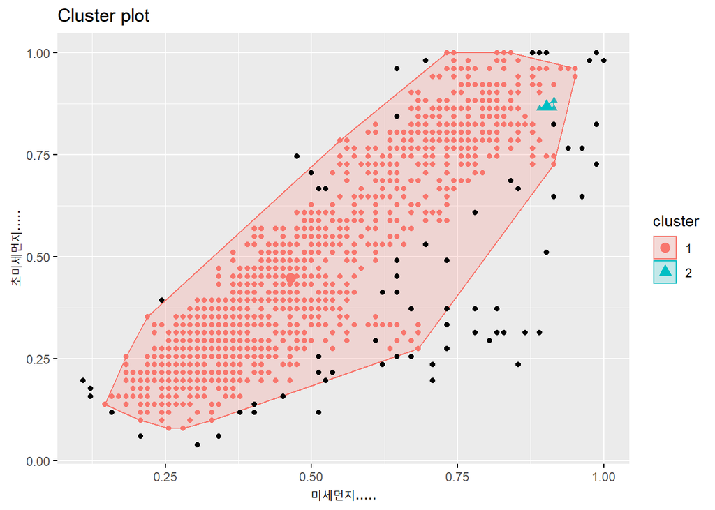

```r
fviz_cluster(ds, air_scaled, stand = FALSE, frame = FALSE, geom = "point")
```

dbscan 결과에 대한 고찰

ㅡㅡㅡㅡㅡㅡㅡㅡㅡㅡㅡㅡㅡㅡㅡㅡㅡㅡㅡㅡㅡㅡㅡㅡㅡㅡㅡㅡㅡㅡㅡㅡㅡㅡㅡㅡㅡㅡㅡㅡㅡㅡㅡ

최종 결과 고찰

kmeans 군집화와 dbscan군집화를 비교하여 보았는데,

kmeans의 경우 대기상태의 구분을 하는데 용이 하였고, dbscan의 경우 대기상태 악화의 특징을 파악하는데 용이 하였다.

데이터를 계절 별로 나누어서 각 계절별 대기 상태를 kmeans로 군집화 하여 보고, 대기 상태 변화의 특징을 dbscan으로 군집화하여본다면

정책이나 대처 방식에 유의미한 결론을 도출 할 수 있을것으로 생각한다